# Data Based Recommendations for A New Movie Project

[figure not shown]

## 1. Objective of the Proposed Research:

We aim to do this by looking at different subsets of the data and various visualizations to get a well-rounded understanding. We aim to bring out factors that could be crucial in making a movie a hit and ultimately successful.

This way, we want to provide Mr. Steven Spielberg who is our stakeholder with concrete data based recommendations. We believe that through our analysis we can make decision-making process of selecting right movies to produce much more reliable and effective.

## 2. Data Exploration:

We will explore the data below using various functions and methods to understand various dimensions of it. This will help us to decide which aspects of the data to target for further exploration. We will also clean the data to remove missing values for better insights

```python
#Importing necessary libraries for data manipulation, numerical operations and plotting

import pandas as pd
import numpy as np
import matplotlib.pyplot as plt
import seaborn as sns
```

```python
#reading dataset and naming it as data

data = pd.read_csv("/content/movies (1).csv")

#Displaying the first 5 rows of the dataset

data.head(5)
```

|  | name | rating | genre | year | released | score | votes | director | writer | star | country | budget | gross | company | runtime |
| --- | --- | --- | --- | --- | --- | --- | --- | --- | --- | --- | --- | --- | --- | --- | --- |
| 0 | The Shining | R | Drama | 1980 | June 13, 1980 (United States) | 8.4 | 927000.0 | Stanley Kubrick | Stephen King | Jack Nicholson | United Kingdom | 19000000.0 | 46998772.0 | Warner Bros. | 146.0 |
| 1 | The Blue Lagoon | R | Adventure | 1980 | July 2, 1980 (United States) | 5.8 | 65000.0 | Randal Kleiser | Henry De Vere Stacpoole | Brooke Shields | United States | 4500000.0 | 58853106.0 | Columbia Pictures | 104.0 |
| 2 | Star Wars: Episode V - The Empire Strikes Back | PG | Action | 1980 | June 20, 1980 (United States) | 8.7 | 1200000.0 | Irvin Kershner | Leigh Brackett | Mark Hamill | United States | 18000000.0 | 538375067.0 | Lucasfilm | 124.0 |
| 3 | Airplane! | PG | Comedy | 1980 | July 2, 1980 (United States) | 7.7 | 221000.0 | Jim Abrahams | Jim Abrahams | Robert Hays | United States | 3500000.0 | 83453539.0 | Paramount Pictures | 88.0 |
| 4 | Caddyshack | R | Comedy | 1980 | July 25, 1980 (United States) | 7.3 | 108000.0 | Harold Ramis | Brian Doyle-Murray | Chevy Chase | United States | 6000000.0 | 39846344.0 | Orion Pictures | 98.0 |

```python
#Checking the dimensions of the data
data.shape
```

```
(7668, 15)
```

```python
#calculate the count of unique values in each column of dataset

data.nunique()
```

```
name        7512
rating        12
genre         19
year          41
released    3414
score         72
votes        936
director    2949
writer      4535
star        2814
country       59
budget       413
gross       7472
company     2385
runtime      138
dtype: int64
```

```python
#Checking the names of columns
columns= data.columns.tolist()
columns
```

```
['name',
 'rating',
 'genre',
 'year',
 'released',
 'score',
 'votes',
 'director',
 'writer',
 'star',
 'country',
 'budget',
 'gross',
 'company',
 'runtime']
```

## 3. Data Cleaning

```python
#check for missing values
missing_values = data.isnull().sum()
missing_values
```

```
name           0
rating        77
genre          0
year           0
released       2
score          3
votes          3
director       0
writer         3
star           1
country        3
budget      2171
gross        189
company       17
runtime        4
dtype: int64
```

```python
#missing value treatment

# we'll fill missing values with the median of each column for column containing numeric data
columns1 = ['budget', 'gross', 'score', 'votes', 'runtime']
for col in columns1:
    median_value = data[col].median()
    data[col].fillna(median_value, inplace=True)

#we'll fill missing values with the mode (most frequest value) of  column for catagorical columns
columns2 = ['rating', 'released', 'writer', 'star', 'country', 'company']
for col in columns2:
    mode_value = data[col].mode()[0]
    data[col].fillna(mode_value, inplace=True)

#confirming the treatment of missing values. 0 denotes no missing value :
data.isnull().sum()
```

```
name        0
rating      0
genre       0
year        0
released    0
score       0
votes       0
director    0
writer      0
star        0
country     0
budget      0
gross       0
company     0
runtime     0
dtype: int64
```

# **4. Subsets & Visualisations:**

We will create subsets of existing dataset in order to generate meaningful insights. We will also create visualization.

**Subset 1 : Top Genres based on Gross Revenue**

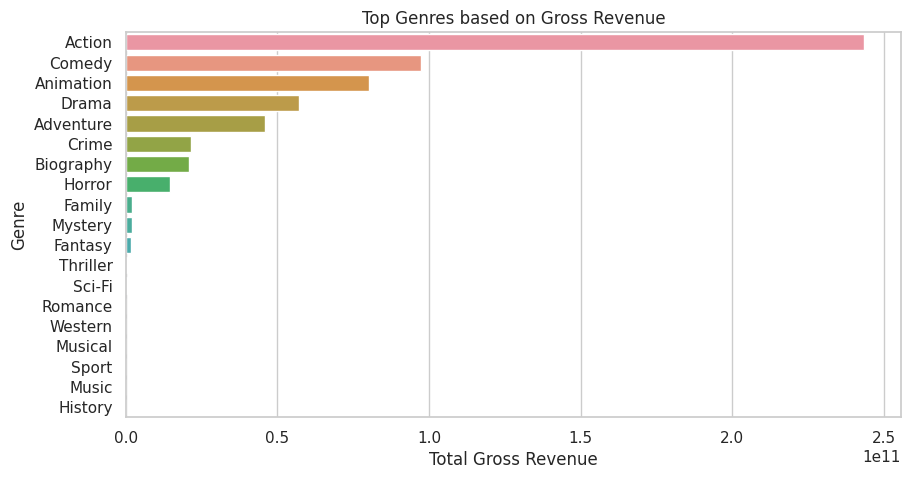

```python
#Top genres by gross revenue
subset1 = data.groupby('genre')['gross'].sum().sort_values(ascending=False).reset_index()

#lets create plot for this :
plt.figure(figsize=(10,5))

sns.barplot(x='gross', y='genre', data=subset1)
plt.title('Top Genres based on Gross Revenue')
plt.xlabel('Total Gross Revenue')
plt.ylabel('Genre')
plt.show()
```

It can be seen that Action genre dominates the data. Followed distantly by comedy.

**Subset2 : Top directors by gross revenue**

```python
#Top directors by gross revenue
subset2 = data.groupby('director')['gross'].sum().sort_values(ascending=False).reset_index().head(5)
subset2
```

|  | director | gross |
| --- | --- | --- |
| 0 | Steven Spielberg | 9.629049e+09 |
| 1 | Anthony Russo | 6.844249e+09 |
| 2 | Peter Jackson | 6.618046e+09 |
| 3 | Michael Bay | 6.451693e+09 |
| 4 | James Cameron | 6.248089e+09 |

**Subset 3 : Top writers by gross revenue**

```python
#Top writers by gross revenue
subset3 = data.groupby('writer')['gross'].sum().sort_values(ascending=False).reset_index().head(5)
subset3
```

|  | writer | gross |
| --- | --- | --- |
| 0 | Christopher Markus | 7.587182e+09 |
| 1 | James Cameron | 6.282146e+09 |
| 2 | John Lasseter | 4.656539e+09 |
| 3 | Chris Morgan | 4.360332e+09 |
| 4 | Steve Kloves | 4.184681e+09 |

**Subset4 : Top stars by gross revenue**

```python
#Top stars by gross revenue
subset4 = data.groupby('star')['gross'].sum().sort_values(ascending=False).reset_index().head(10)
subset4
```

|  | star | gross |
| --- | --- | --- |
| 0 | Robert Downey Jr. | 1.185953e+10 |
| 1 | Tom Hanks | 9.952424e+09 |
| 2 | Tom Cruise | 9.602553e+09 |
| 3 | Daniel Radcliffe | 7.954065e+09 |
| 4 | Will Smith | 7.947279e+09 |
| 5 | Johnny Depp | 7.444239e+09 |
| 6 | Leonardo DiCaprio | 6.963368e+09 |
| 7 | Vin Diesel | 6.036313e+09 |
| 8 | Dwayne Johnson | 5.711271e+09 |
| 9 | Bruce Willis | 5.318951e+09 |

**Subset 5 : Gross revenue by country**

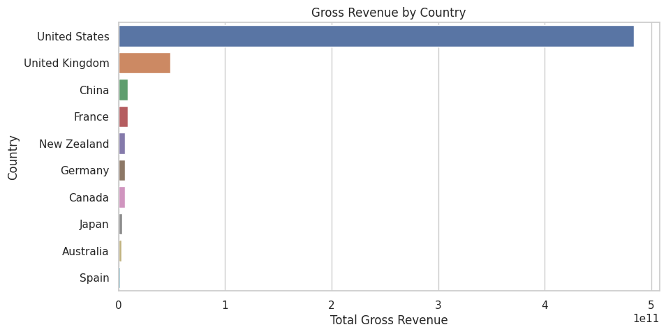

```python
#Gross revenue by country
subset5 = data.groupby('country')['gross'].sum().sort_values(ascending=False).reset_index().head(10)

#plotting this on barplot :

plt.figure(figsize=(10, 5))
sns.barplot(x='gross', y='country', data=subset5)

plt.title('Gross Revenue by Country')
plt.xlabel('Total Gross Revenue')
plt.ylabel('Country')
plt.show()
```

UNited states outperform as country based market among all other markets

### Subset 6 : Top producing companies based on gross revenue

```python
# displaying top 5 companies based on gross earning of a movie
top_company = data1.groupby('company')['gross'].sum().reset_index()

top_company = top_company.sort_values(by='gross', ascending=False).head(5)

top_company
```

|  | company | gross |
| --- | --- | --- |
| 1426 | Warner Bros. | 5.461096e+10 |
| 1397 | Universal Pictures | 5.124111e+10 |
| 452 | Columbia Pictures | 4.235643e+10 |
| 1108 | Paramount Pictures | 4.002170e+10 |
| 1382 | Twentieth Century Fox | 3.954257e+10 |

**Subset 7 : Top writers based on IMDb rating score**

```python
#top writers based on highest total gross earning by a films written by them
top_writers = data.groupby('writer')['score'].sum().nlargest(5).reset_index(name='highest ')
print(top_writers)
```

```
         writer  highest
0   Woody Allen     258.6
1  Stephen King     200.8
2    Luc Besson     172.6
3   John Hughes     162.0
4   David Mamet     103.0
```

```python
#correlation matrix
correlation_matrix = data.corr()

#heatmap creation
plt.figure(figsize=(12, 8))
sns.heatmap(correlation_matrix, annot=True, cmap='coolwarm')
plt.title('Correlation Matrix Heatmap')
plt.show()
```

[output not shown]

It can be seen that there is little correlation between gross earning and IMDb score. However **a fairly good positive correlation exists between budget of the film and its earning**

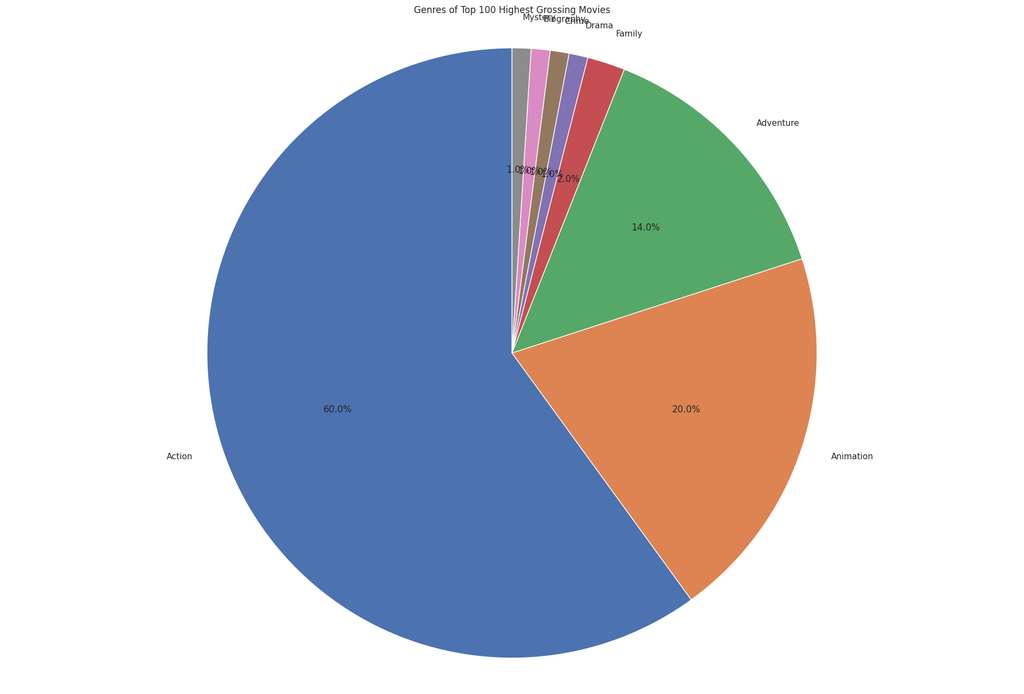

```python
import matplotlib.pyplot as plt

# sorting the data by 'gross' to find top 100 movies
top_100_movies = data.sort_values('gross', ascending=False).head(100)

#count the number of movies for each genre in the top 100 list
genre_count = top_100_movies['genre'].value_counts()

# Create the pie chart
plt.figure(figsize=(24, 16))
plt.pie(genre_count, labels=genre_count.index, autopct='%1.1f%%', startangle=90)
plt.title('Genres of Top 100 Highest Grossing Movies')
plt.axis('equal')
plt.show()
```

Among top 100 films by revenue, Action films constitute 60% share. followed by Animation (20%) and Adventure (14%). Other genres have insignificant shares

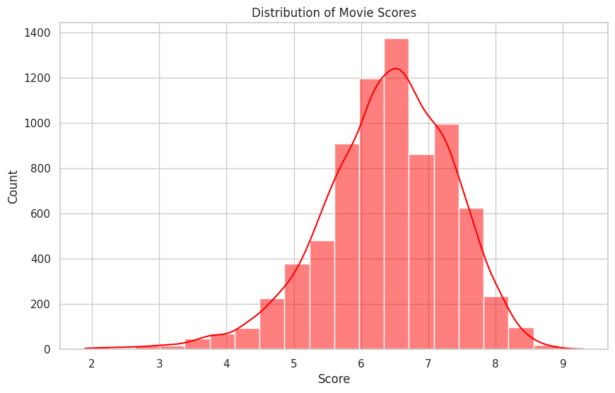

```python
plt.figure(figsize=(10, 6))
sns.histplot(data['score'], bins=20, kde=True, color='Red')
plt.title('Distribution of Movie Scores')
plt.xlabel('Score')
plt.show()
```

Most movie ratings falls between 5.5 to 7.5 with most movies getting 6-7 rating on IMDb

## 6. Summary

**Top Directors by Gross Revenue:**

Steven Spielberg is the director whose movies have earned the most, followed by Anthony Russo and Peter Jackson.

**Top Writers by Gross Revenue:**

Christopher Markus tops the list, followed by James Cameron and John Lasseter.

**Top Stars by Gross Revenue:**

Robert Downey Jr.'s movies have the highest gross revenue, followed by Tom Hanks and Tom Cruise.

**Gross Revenue by Country:**

The United States is the country where movies make the most money, by a big margin.

**Top 5 Companies Based on Gross Earning:**

Warner Bros. is the top company, followed by Universal Pictures and Columbia Pictures.

**Top Writers Based on Score:** Woody Allen has the highest total movie scores, followed by Stephen King and Luc Besson.

**Correlation Matrix:** There is a positive correlation between 'gross' and 'votes', and between 'score' and 'votes'. And there is little correlation between gross earning and IMDb ratings meaning that a movie can be critically well received but may not do well commercially.

**Genres of Top 100 Highest Grossing Movies:** Action, Adventure, and Animation are the most common genres in the top 100 highest-grossing movies.

**Distribution of Movie Scores:** Most movies have scores between 6 and 8.

## 7. Recommendations

**Director Selection:**

It is proven by our data that you are the most successful director. However in case you are looking for alternatives, directors like Anthony Russo or Peter Jackson have also shown strong financial performance.

**Writer Selection:**

Christopher Markus or James Cameron have penned movies with substantial gross revenue. While, writers like Woody Allen and Stephen King have contributed to films with high scores, indicating strong storytelling capabilities.

**Star Selection:**

We recommend Robert Downey Jr., Tom Hanks, or Tom Cruise since hese stars have been part of movies with the highest gross revenue, thereby potentially maximizing box office returns.

**Country of Release:**

Prioritize the United States: our data indicates that movies generate the highest gross revenue in the United States, making it a key market. Hence a movie where US people can identify with can be potential success.

**Production Company:**

We highly recommend you to Collaborate with Warner Bros. or Universal Pictures: These companies have the highest grossing films, offering a reliable partnership for financial success.

**Votes and Gross Revenue:**

There is a positive correlation between the number of votes and gross revenue, implying that marketing strategies should aim to engage more audience participation.

**Scores and Votes:** Movies with higher scores also tend to get more votes, emphasizing the importance of quality storytelling.

**Critcal Vs. Commercial Success** A good score on IMDb does not translate to commerical success of the film.

We understand that film-making is an art. However, by aligning your new project with these data-driven insights, we strongly believe that a movie can be made successful.